# Split up plots of gene body features in different gene classes

Léonie Strömich

August 28, 2017

Script to plot single plots of gene body feature distribution over gene classes. Takes as input the matrix calculated in “plot_all_features_new_gene_classes.Rmd” and slices it.

## Prerequisites

#### Load libraries

```r
library(ggplot2)
library(raster)
library(reshape2)
library(scales)
library(RColorBrewer)
```

#### Read in data

```r
# RDS objects in Transfer/rds_objects
##read in count matrices
counts_mTECs <- readRDS(file="/home/stroemic/hiwi_16/analysis/gene_lists/new_classes_tss_oe_tra_san_aire_san_counts_mTECs_matrix_human_filt.rds")
counts_tissues <- readRDS(file="/home/stroemic/hiwi_16/analysis/gene_lists/new_classes_tss_oe_tra_san_aire_san_counts_tissues_matrix_human_filt.rds")
```

## Analysis

Matrix with the following set up is taken as basis for all plots: 12 rows:

1. TSS_10
2. TSS_100
3. first_exon
4. TSS_10_other_exons
5. TSS_100_other_exons
6. TTS_100
7. upstream
8. other_exon
9. intron
10. antisense
11. downstream
12. intergenic

12 columns:

1. aire_dep_tras_mTECs
2. fezf2_dep_tras_mTECs
3. other_tras_mTECs
4. hk_mTECs
5. other_genes_mTECs
6. rest_mTECs
7. aire_dep_tras_tissues
8. fezf2_dep_tras_tissues
9. other_tras_tissues
10. hk_tissues
11. other_genes_tissues
12. rest_tissues

Pre-processing

```r
#bind matrices together
counts <- cbind(counts_mTECs, counts_tissues)
#discard last row and columns
counts_trunc <- counts[-12,-c(6,12)]
# calculate a percentage matrix
counts_trunc <- t(t(counts_trunc)/rowSums(t(counts_trunc)))
```

#### Plot 1

Pattern around TSS in mTECs Distribution of tags to features: TSS10, TS100, First exon second half of the plot are features in tissues

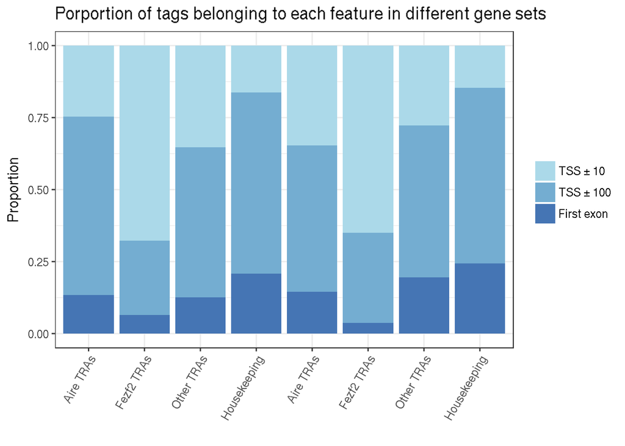

```r
###1. TSS pattern
#A comparison mTECs / tissues

#take relevant columns and rows
counts_TSS <- counts[c(1:3),c(1:4,7:10)] ####change here
#melt for plotting
m_counts_TSS <- melt(counts_TSS)
#keep ordering of factors
m_counts_TSS <- transform(m_counts_TSS, feature_class = factor(Var1, rownames(counts_TSS)),
                      gene_class = factor(Var2, colnames(counts_TSS)))

#pdf(file ="/home/stroemic/hiwi_16/analysis/gene_lists/plots/Final/TSS_patterns_mTECs_vs_tissues_final.pdf")
my.labs <- list("TSS \u00B1 10","TSS \u00B1 100","First exon")
my.x.labs <- list("Aire TRAs","Fezf2 TRAs","Other TRAs","Housekeeping","Aire TRAs","Fezf2 TRAs","Other TRAs","Housekeeping")
print(ggplot(m_counts_TSS, aes(x=gene_class,y=value,fill=feature_class)) +
        geom_bar(position = "fill", stat = "identity") +
        labs(title="Porportion of tags belonging to each feature in different gene sets", x ="", y ="Proportion") +
        theme_bw() +
        theme(axis.text.x=element_text(angle=60, hjust=1, size=10)) +
        scale_x_discrete(labels = my.x.labs) +
        #scale_fill_brewer(palette="Blues") +
        scale_fill_manual(values = c('#abd9e9','#74add1','#4575b4'), labels = my.labs) +
        guides(fill=guide_legend(title=NULL))
)
```

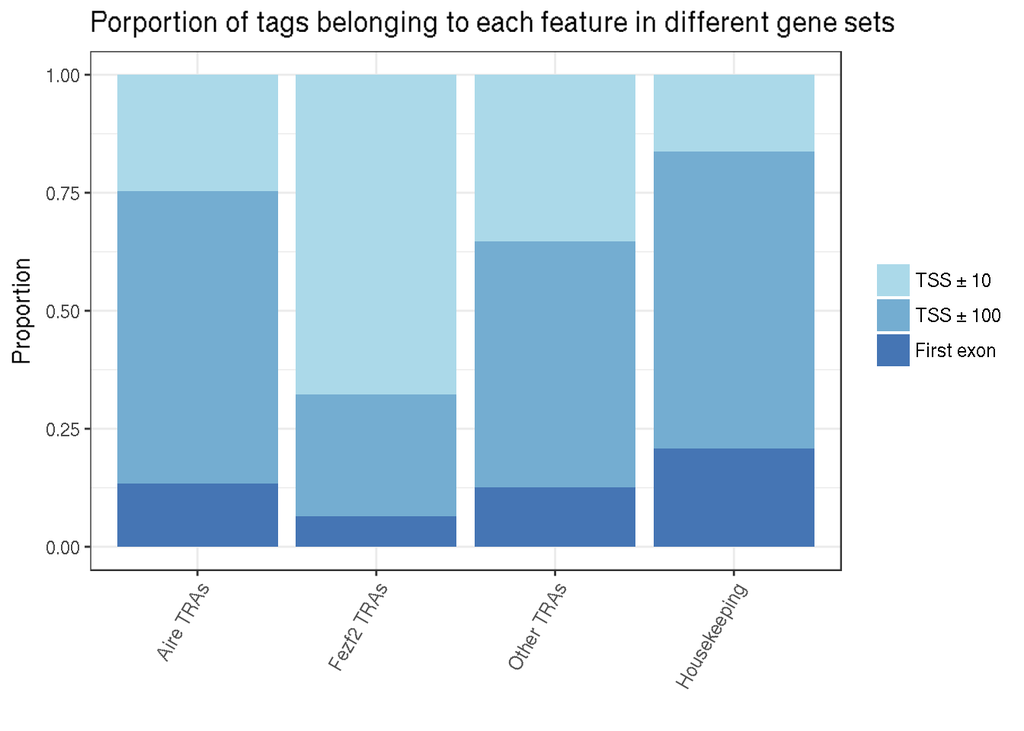

```r
#dev.off()

#B comparison of gene classes in mTECs only
counts_TSS <- counts[c(1:3),c(1:4)] ####change here
#melt for plotting
m_counts_TSS <- melt(counts_TSS)
#keep ordering of factors
m_counts_TSS <- transform(m_counts_TSS, feature_class = factor(Var1, rownames(counts_TSS)),
                          gene_class = factor(Var2, colnames(counts_TSS)))

#pdf(file ="/home/stroemic/hiwi_16/analysis/gene_lists/plots/Final/TSS_patterns_mTECs_only_final.pdf")
my.labs <- list("TSS \u00B1 10","TSS \u00B1 100","First exon")
my.x.labs <- list("Aire TRAs","Fezf2 TRAs","Other TRAs","Housekeeping")
print(ggplot(m_counts_TSS, aes(x=gene_class,y=value,fill=feature_class)) +
        geom_bar(position = "fill", stat = "identity") +
        labs(title="Porportion of tags belonging to each feature in different gene sets", x ="", y ="Proportion") +
        theme_bw() +
        theme(axis.text.x=element_text(angle=60, hjust=1, size=10)) +
        scale_x_discrete(labels = my.x.labs) +
        #scale_fill_brewer(palette="Blues") +
        scale_fill_manual(values = c('#abd9e9','#74add1','#4575b4'), labels = my.labs) +
        guides(fill=guide_legend(title=NULL))

)
```

```r
#dev.off()
```

#### Plot 2

Intronic and antisense tags in different gene classes second half of the plot are features in tissues

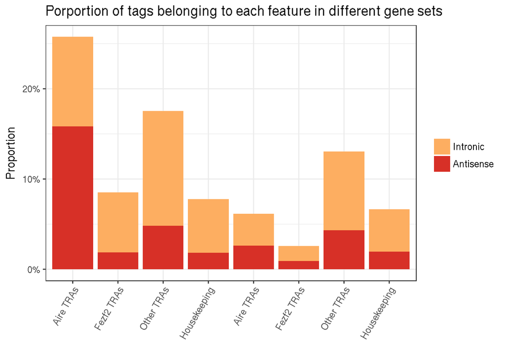

```r
###2. Intronic/Antisense high in Aire regulated TRAs
#take relevant columns and rows of percentage matrix
perc_intron_anti <- counts_trunc[c(9:10),c(1:4,6:9)] ####change here
#melt for plotting
m_perc_intron_anti <- melt(perc_intron_anti)
#keep ordering of factors
m_perc_intron_anti <- transform(m_perc_intron_anti, feature_class = factor(Var1, rownames(perc_intron_anti)),
                          gene_class = factor(Var2, colnames(perc_intron_anti)))

#pdf(file ="/home/stroemic/hiwi_16/analysis/gene_lists/plots/Final/intronic_antisense_mTECs_tissues_final.pdf")
my.labs <- list("Intronic","Antisense")
my.x.labs <- list("Aire TRAs","Fezf2 TRAs","Other TRAs","Housekeeping","Aire TRAs","Fezf2 TRAs","Other TRAs","Housekeeping")
print(ggplot(m_perc_intron_anti, aes(x=gene_class,y=value,fill=feature_class)) +
        geom_bar(stat = "identity") +
        labs(title="Porportion of tags belonging to each feature in different gene sets", x ="", y ="Proportion") +
        theme_bw() +
        theme(axis.text.x=element_text(angle=60, hjust=1, size=10)) +
        #scale_fill_brewer(palette="Blues") +
        scale_fill_manual(values = c('#fdae61','#d73027'), labels = my.labs) +
        scale_x_discrete(labels = my.x.labs) +
        guides(fill=guide_legend(title=NULL)) +
        scale_y_continuous(labels = percent)

)
```

```r
#dev.off()
```

#### Plot 3

Tags at Intron/Exon boundaries second half of the plot are features in tissues

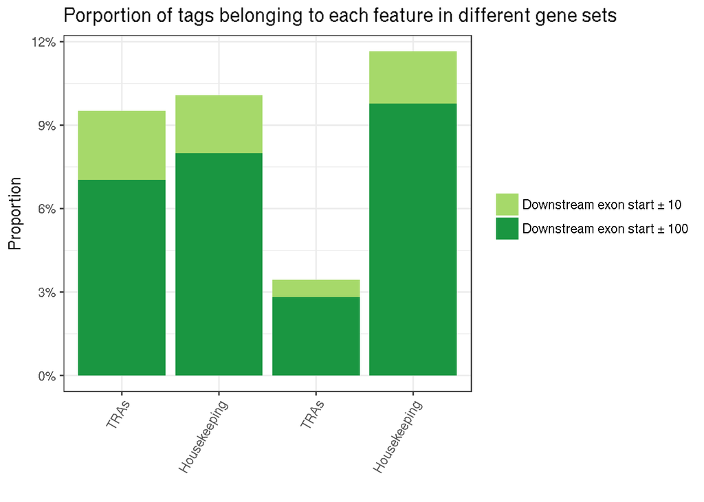

```r
###3. TSS at other exons
#A comparison mTECs / tissues as whole with newly calculated percentages --> real data
#built dataframe with sum up of tra columns
df_tss_oe <- data.frame("feature"=rownames(counts), "tras_mTECs"=(counts[,1]+counts[,2]+counts[,3]),
                        "hk_mTECs"=counts[,4],
                        "tras_tissues"=(counts[,7]+counts[,8]+counts[,9]),
                        "hk_tissues"=counts[,10])

#dataframe to matrix
tss_oe <- data.matrix(df_tss_oe[,2:5])
#calculate percentages over columns
perc_tss_oe <- t(t(tss_oe)/rowSums(t(tss_oe)))
#take relevant rows with information on TSS around other exons
perc_tss_oe <- perc_tss_oe[4:5,]
#melt for plotting
m_perc_tss_oe <- melt(perc_tss_oe)
#keep ordering of factors
m_perc_tss_oe<- transform(m_perc_tss_oe, feature_class = factor(Var1, rownames(perc_tss_oe)),
                          gene_class = factor(Var2, colnames(perc_tss_oe)))

#pdf(file ="/home/stroemic/hiwi_16/analysis/gene_lists/plots/Final/tss_oe_mTECs_tissues_final.pdf")
my.labs <- list("Downstream exon start \u00B1 10","Downstream exon start \u00B1 100")
my.x.labs <- list("TRAs","Housekeeping","TRAs","Housekeeping")
print(ggplot(m_perc_tss_oe, aes(x=gene_class,y=value,fill=feature_class)) +
        geom_bar(stat = "identity") +
        labs(title="Porportion of tags belonging to each feature in different gene sets", x ="", y ="Proportion") +
        theme_bw() +
        theme(axis.text.x=element_text(angle=60, hjust=1, size=10)) +
        #scale_fill_brewer(palette="Blues") +
        scale_fill_manual(values = c('#a6d96a','#1a9641'), labels = my.labs) +
        scale_x_discrete(labels = my.x.labs) +
        guides(fill=guide_legend(title=NULL)) +
        scale_y_continuous(labels = percent)

)
```

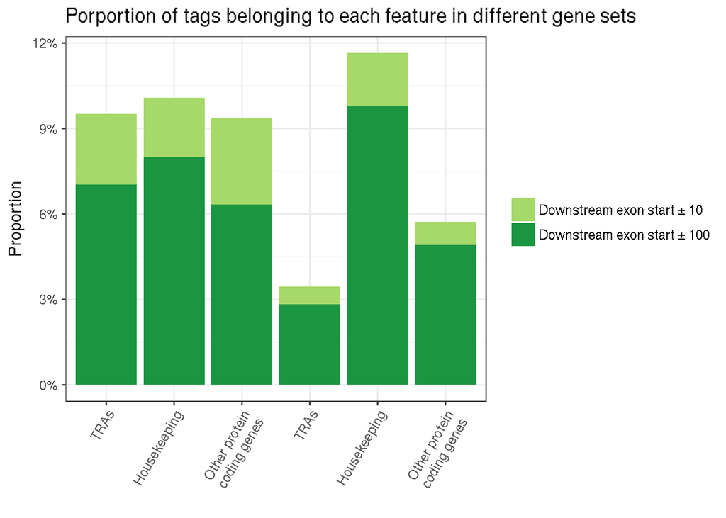

```r
#dev.off()


#B comparison mTECs / tissues as whole with newly calculated percentages --> real data with protein coding
#built dataframe with sum up of tra columns include other protein coding genes
df_tss_oe <- data.frame("feature"=rownames(counts), "tras_mTECs"=(counts[,1]+counts[,2]+counts[,3]),
                        "hk_mTECs"=counts[,4],
                        "others_mTECs"=counts[,5],
                        "tras_tissues"=(counts[,7]+counts[,8]+counts[,9]),
                        "hk_tissues"=counts[,10],
                        "others_tissues"=counts[,11])

#dataframe to matrix
tss_oe <- data.matrix(df_tss_oe[,2:7])
#calculate percentages over columns
perc_tss_oe <- t(t(tss_oe)/rowSums(t(tss_oe)))
#take relevant rows with information on TSS around other exons
perc_tss_oe <- perc_tss_oe[4:5,]
#melt for plotting
m_perc_tss_oe <- melt(perc_tss_oe)
#keep ordering of factors
m_perc_tss_oe<- transform(m_perc_tss_oe, feature_class = factor(Var1, rownames(perc_tss_oe)),
                          gene_class = factor(Var2, colnames(perc_tss_oe)))

#pdf(file ="/home/stroemic/hiwi_16/analysis/gene_lists/plots/Final/tss_oe_mTECs_tissues_final_protein_coding_genes.pdf")
my.labs <- list("Downstream exon start \u00B1 10","Downstream exon start \u00B1 100")
my.x.labs <- list("TRAs","Housekeeping","Other protein\ncoding genes","TRAs","Housekeeping","Other protein\ncoding genes")
print(ggplot(m_perc_tss_oe, aes(x=gene_class,y=value,fill=feature_class)) +
         geom_bar(stat = "identity") +
        labs(title="Porportion of tags belonging to each feature in different gene sets", x ="", y ="Proportion") +
        theme_bw() +
        theme(axis.text.x=element_text(angle=60, hjust=1, size=10)) +
        #scale_fill_brewer(palette="Blues") +
        scale_fill_manual(values = c('#a6d96a','#1a9641'), labels = my.labs) +
        scale_x_discrete(labels = my.x.labs) +
        guides(fill=guide_legend(title=NULL)) +
        scale_y_continuous(labels = percent)

)
```

```r
#dev.off()
```